# Neural Networks Ghazal Kalhor

*Abstract* — In this computer assignment, we want to classify given photos from lungs of humans into three classes using Neural Networks that we learnt in Artificial Intelligence. We will build our neural network using Keras library. *Keywords* — Artificial Intelligence, Keras, Neural Networks

### **Introduction**

The aim of this computer assignment is to make an optimal neural network in order to classify the photos of the humans' lung into `Covid19`, `Normal`, and `Penumonia` classes.

### **Importing Libraries**

In this part, some of the necessary libraries were imported in order to use their helpful functions.

```python
import numpy as np
from tensorflow.keras import *
import matplotlib.pyplot as plt
from sklearn.metrics import classification_report
```

### **Defining Constants**

In this part, constant values are defined in order to make the code more readable and more flexible to change.

```python
N_CLASSES = 3
TRAIN_DIR = "/content/Data/train"
TEST_DIR = "/content/Data/test"
```

### **Importing Data**

In this part, file *xray.zip* is coppied to the project directory, then we unzipped it and put its data into *train* and *test* sub-directories.

```python
!cp "/content/drive/MyDrive/xray.zip" .
```

```python
!unzip xray.zip
```

[output not shown]

[output cut: 2601 more lines]

[output not shown]

### **Question 1**

In this part, we read test and train data, using `ImageDataGenerator()` method from Keras library.Then we performed some preprocessing on the images. Moreover, we set the batch-size to 32 for the training process.

```python
data_generator = preprocessing.image.ImageDataGenerator()
```

```python
def get_data(data_generator, file_path):
    data = data_generator.flow_from_directory(
        file_path,
        target_size = (80, 80),
        color_mode = "grayscale",
        batch_size = 32
    )
    return data
```

In this part, we printed the number of instances of each class in test and train data.

```python
train_data = get_data(data_generator, TRAIN_DIR)
```

```
Found 5144 images belonging to 3 classes.
```

```python
test_data = get_data(data_generator, TEST_DIR)
```

```
Found 1288 images belonging to 3 classes.
```

### **Question 2: Visualization**

#### **Plotting a Sample of each Class**

```python
images, labels = train_data.next()
```

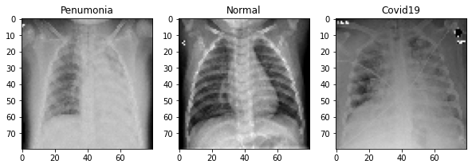

```python
fig, ax = plot_container = plt.subplots(1, 3)
fig.set_size_inches(10, 4)

label_dict = {0:'Covid19', 1:'Normal', 2:'Penumonia'}

cursor = 0
seen = list()

for image, label in zip(images, labels):
    class_label = backend.argmax(label).numpy()
    if class_label not in seen:
        ax[cursor].imshow(image.reshape(80, 80), cmap='gray')
        ax[cursor].set_title(label_dict[class_label])
        seen.append(class_label)
        cursor += 1
```

#### **Plotting Frequency of each Class**

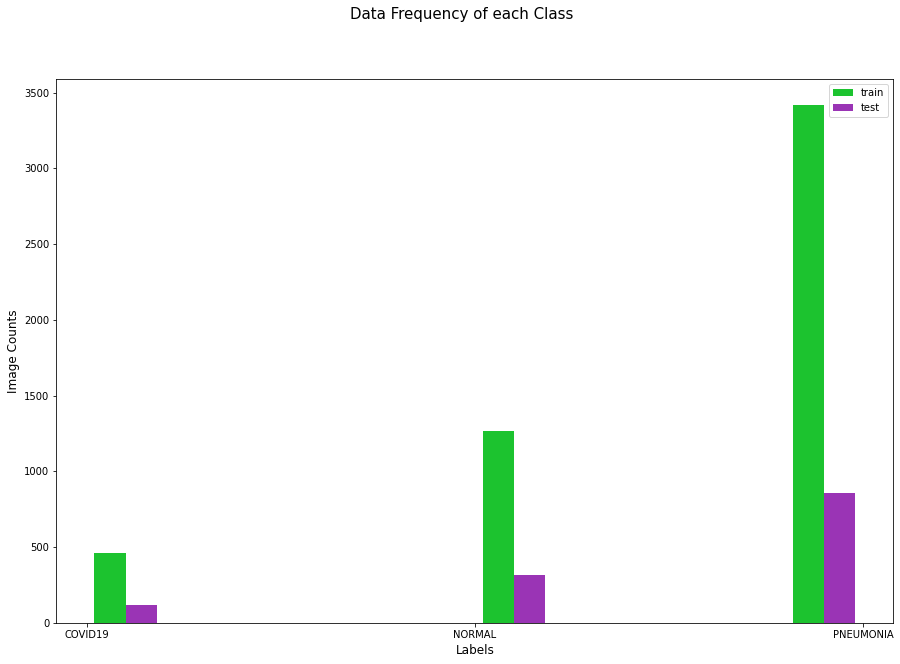

```python
fig = plt.figure(figsize=(15, 10))
labels = (train_data.classes, test_data.classes)
plt.hist(labels, label=['train', 'test'], color=['#1cc32f', '#9a34b5'])
plt.xlabel('Labels', fontsize = 12)
plt.ylabel('Image Counts', fontsize = 12)
plt.suptitle('Data Frequency of each Class', fontsize = 15)
plt.legend()
loc = list(train_data.class_indices.values())
my_xticks = list(train_data.class_indices.keys())
plt.xticks(loc, my_xticks)
plt.show()
```

### **Question 3**

In this part, we implemented necessary functions to make a neural network with and without dropout layers. Also, we set default values for some hyperparameters based on the project description.

```python
def make_feedforward_network(neurons_1st_dense, neurons_2nd_dense, neurons_3rd_dense, activation='relu',
                             optimizer=optimizers.SGD(), loss=losses.categorical_crossentropy,
                             regularizer=None):
    inp = layers.Input(shape=(80, 80, 1))
    out = layers.Flatten()(inp)
    out = layers.Dense(neurons_1st_dense, activation=activation, kernel_regularizer=regularizer)(out)
    out = layers.Dense(neurons_2nd_dense, activation=activation, kernel_regularizer=regularizer)(out)
    out = layers.Dense(neurons_3rd_dense, activation=activation, kernel_regularizer=regularizer)(out)
    out = layers.Dense(N_CLASSES, activation="softmax")(out)

    model = models.Model(inputs=inp, outputs=out)
    model.compile(optimizer=optimizer, loss=loss, metrics=['accuracy'])
    return model
```

```python
def make_feedforward_network_with_dropout(neurons_1st_dense, neurons_2nd_dense, neurons_3rd_dense, dropout, \
                                          activation='relu', optimizer=optimizers.SGD(), \
                                          loss=losses.categorical_crossentropy, regularizer=None):
    inp = layers.Input(shape=(80, 80, 1))
    out = layers.Flatten()(inp)
    out = layers.Dense(neurons_1st_dense, activation=activation, kernel_regularizer=regularizer)(out)
    out = layers.Dropout(dropout)(out)
    out = layers.Dense(neurons_2nd_dense, activation=activation, kernel_regularizer=regularizer)(out)
    out = layers.Dropout(dropout)(out)
    out = layers.Dense(neurons_3rd_dense, activation=activation, kernel_regularizer=regularizer)(out)
    out = layers.Dropout(dropout)(out)
    out = layers.Dense(N_CLASSES, activation="softmax")(out)

    model = models.Model(inputs=inp, outputs=out)
    model.compile(optimizer=optimizer, loss=loss, metrics=['accuracy'])
    return model
```

#### **Constructing FeedForward Neural Network**

```python
relu_model = make_feedforward_network(4800, 3200, 1600)
```

#### **Parameters of the Model**

In this part, we use `summary()` method to check the parameters of our model.

Each row represents a layer with each named uniquely such that we can refer to these layers without any ambiguity. As you can see, the layers that we added to the model in the previous code snippet are all included in the output.

Each layer has an output and its shape is shown in the **Output Shap** column Each layer’s output becomes the input for the subsequent layer.

The **Param #** column shows the number of parameters that are trained for each layer.

The total number of parameters is shown at the end, which is equal to the number of trainable and non-trainable parameters. In this model, all the parmeters are trainable.

```python
relu_model.summary()
```

```
Model: "model"
_________________________________________________________________
Layer (type)                 Output Shape              Param #
=================================================================
input_1 (InputLayer)         [(None, 80, 80, 1)]       0
_________________________________________________________________
flatten (Flatten)            (None, 6400)              0
_________________________________________________________________
dense (Dense)                (None, 4800)              30724800
_________________________________________________________________
dense_1 (Dense)              (None, 3200)              15363200
_________________________________________________________________
dense_2 (Dense)              (None, 1600)              5121600
_________________________________________________________________
dense_3 (Dense)              (None, 3)                 4803
=================================================================
Total params: 51,214,403
Trainable params: 51,214,403
Non-trainable params: 0
_________________________________________________________________
```

The number of parameters for each layer can be computed using the following formula:

*# of parameters = (# of inputs + 1)* (# of outputs)*

1 in the above formula refers to the bias term and the product shows the number of edges from the previous layer to the current layer. We need to compute the weights of these edges in our training process.

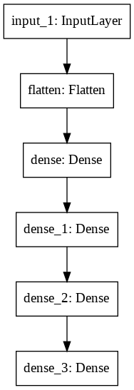

```python
utils.plot_model(relu_model)
```

### **Question 4**

#### **Defining Methods for Training**

```python
def get_labels(data):
    target_labels = []
    for i in range(int(np.ceil(len(data.classes)/data.batch_size))):
        images, labels = data.next()
        for label in labels:
            target_labels.append(backend.argmax(label))
        target_labels = np.array(target_labels)
    return target_labels
```

```python
def print_metrics(true_outputs, expected_outputs):
    true_outputs = np.array(backend.argmax(true_outputs))
    print(classification_report(expected_outputs, true_outputs))
```

```python
def predict(model, test_data):
    expected_outputs = get_labels(test_data)
    true_outputs = model.predict(test_data)
    print_metrics(true_outputs, expected_outputs)
```

```python
def plot_loss(history):
    fig = plt.figure(figsize=(15, 10))
    plt.plot(history.history['loss'], linewidth = 3, color = '#e500a9')
    plt.plot(history.history['val_loss'], linewidth = 3, color = '#9a34b5')
    plt.title('Model Loss', fontsize = 15)
    plt.ylabel('Loss', fontsize = 12)
    plt.xlabel('Epoch', fontsize = 12)
    plt.legend(['Train', 'Test'], loc='upper left')
    plt.show()
```

#### **Training with ReLU Activation Function**

When we use this activation function, we face with the nan loss values and this happend because we did not normalize the photos in the previous parts. Moreover, we have died relu and the accuracy of our model is not updating.

```python
history = relu_model.fit(train_data, validation_data=test_data, epochs=10)
```

```python
predict(relu_model, test_data)
```

```
              precision    recall  f1-score   support

           0       0.09      1.00      0.17       116
           1       0.00      0.00      0.00       317
           2       0.00      0.00      0.00       855

    accuracy                           0.09      1288
   macro avg       0.03      0.33      0.06      1288
weighted avg       0.01      0.09      0.01      1288
```

[figure not shown]

```python
plot_loss(history)
```

#### **Training with Tanh Activation Function**

When we use the tanh activation function, gradients get smaller and smaller during the time. Therefore, neurons of the first layers do the learning process slower than neurons of the last layers. This can make the learning process longer. As a result, the accuracy of the model will be reduced.

```python
tanh_model = make_feedforward_network(4800, 3200, 1600, activation='tanh')
```

```python
history = tanh_model.fit(train_data, validation_data=test_data, epochs=10)
```

```python
predict(tanh_model, test_data)
```

```
              precision    recall  f1-score   support

           0       0.00      0.00      0.00       116
           1       0.00      0.00      0.00       317
           2       0.66      1.00      0.80       855

    accuracy                           0.66      1288
   macro avg       0.22      0.33      0.27      1288
weighted avg       0.44      0.66      0.53      1288
```

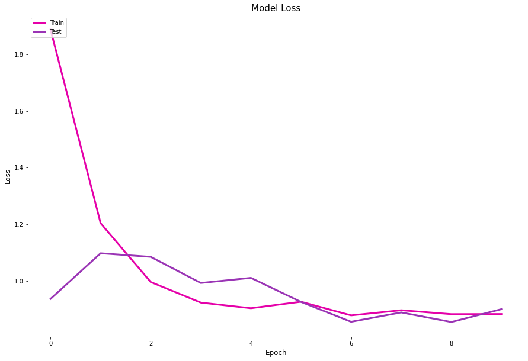

```python
plot_loss(history)
```

#### **Comparison between Two Activation Functions**

In both, our model is not updating and it seems that the process of training has been stopped. But the loss for the relu gets nan value and this refers to the definition of this function.

One technique to deal with this problem is to normalize the data before learning.

### **Question 5**

```python
rescaled_data_generator = preprocessing.image.ImageDataGenerator(
    rescale=1. / 255
)
```

```python
rescaled_train = get_data(rescaled_data_generator, TRAIN_DIR)
```

```
Found 5144 images belonging to 3 classes.
```

```python
rescaled_test = get_data(rescaled_data_generator, TEST_DIR)
```

```
Found 1288 images belonging to 3 classes.
```

```python
optimal_model = make_feedforward_network(4800, 3200, 1600)
history = optimal_model.fit(rescaled_train, validation_data=rescaled_test, epochs=10)
```

```python
predict(optimal_model, rescaled_test)
```

```
              precision    recall  f1-score   support

           0       0.98      0.87      0.92       116
           1       0.91      0.91      0.91       317
           2       0.96      0.97      0.96       855

    accuracy                           0.95      1288
   macro avg       0.95      0.92      0.93      1288
weighted avg       0.95      0.95      0.95      1288
```

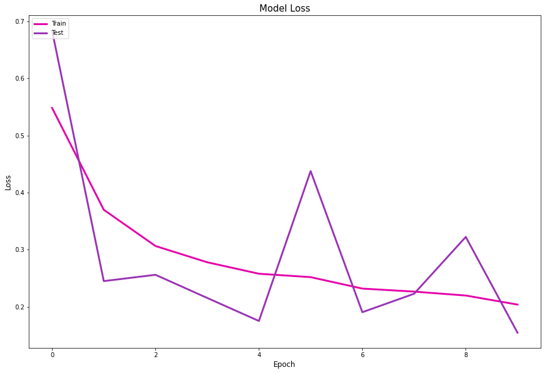

```python
plot_loss(history)
```

### **Question 6**

#### **What is momentum in neural networks?**

Momentum or SGD with momentum is a method which helps us to accelerate gradient vectors in the right directions. Momentum is an average of gradients that changes during the time and we use it to update weight in each step. Therefore, it leads to faster convergence. It is mostly used in neural networks considering the size of data in NNs makes a considerable time difference while training gradients. It can be used to handle noisy gradients. Moreover, it can handle extremely small gradients.

#### **Setting Momentum to 0.5**

```python
model_6_1 = make_feedforward_network(4800, 3200, 1600, optimizer=optimizers.SGD(momentum=0.5))
history_6_1 = model_6_1.fit(rescaled_train, validation_data=rescaled_test, epochs=10)
```

```python
predict(model_6_1, rescaled_test)
```

```
              precision    recall  f1-score   support

           0       0.83      0.98      0.90       116
           1       0.95      0.85      0.90       317
           2       0.95      0.96      0.95       855

    accuracy                           0.94      1288
   macro avg       0.91      0.93      0.92      1288
weighted avg       0.94      0.94      0.94      1288
```

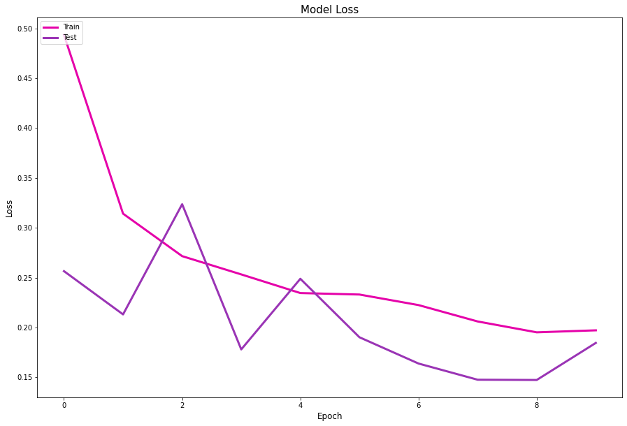

```python
plot_loss(history_6_1)
```

Based on the result, this model is more optimal in comparison to the other model (with another values for momentum) and the loss decreases with higher rate.

#### **Setting Momentum to 0.9**

```python
model_6_2 = make_feedforward_network(4800, 3200, 1600, optimizer=optimizers.SGD(momentum=0.9))
history_6_2 = model_6_2.fit(rescaled_train, validation_data=rescaled_test, epochs=10)
```

```python
predict(model_6_2, rescaled_test)
```

```
              precision    recall  f1-score   support

           0       0.94      0.91      0.92       116
           1       0.87      0.94      0.90       317
           2       0.97      0.95      0.96       855

    accuracy                           0.94      1288
   macro avg       0.93      0.93      0.93      1288
weighted avg       0.94      0.94      0.94      1288
```

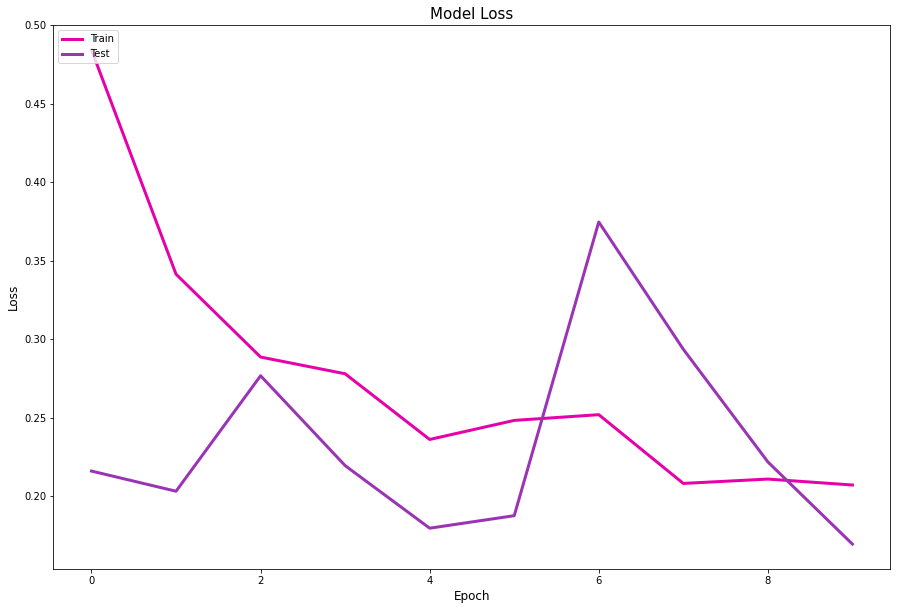

```python
plot_loss(history_6_2)
```

Based on the result, using 0.9 for momentum does not have any positive effect and the rate of the changing in loss has been decreased.

#### **Setting Momentum to 0.99**

```python
model_6_3 = make_feedforward_network(4800, 3200, 1600, optimizer=optimizers.SGD(momentum=0.99))
history_6_3 = model_6_3.fit(rescaled_train, validation_data=rescaled_test, epochs=10)
```

```python
predict(model_6_3, rescaled_test)
```

```
              precision    recall  f1-score   support

           0       0.00      0.00      0.00       116
           1       0.98      0.54      0.70       317
           2       0.76      1.00      0.87       855

    accuracy                           0.79      1288
   macro avg       0.58      0.51      0.52      1288
weighted avg       0.75      0.79      0.75      1288
```

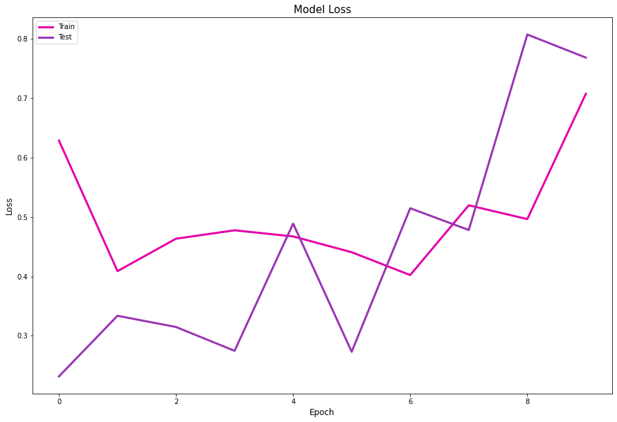

```python
plot_loss(history_6_3)
```

Base on the result, the weights in this model are not updating in a correct direction and it seems that this model will not reach to an optimal solution.

#### **Using Adam Optimizer**

```python
adam_model = make_feedforward_network(4800, 3200, 1600, optimizer=optimizers.Adam())
adam_history = adam_model.fit(rescaled_train, validation_data=rescaled_test, epochs=10)
```

```python
predict(adam_model, rescaled_test)
```

```
              precision    recall  f1-score   support

           0       0.89      0.97      0.93       116
           1       0.80      0.94      0.86       317
           2       0.98      0.90      0.94       855

    accuracy                           0.92      1288
   macro avg       0.89      0.94      0.91      1288
weighted avg       0.93      0.92      0.92      1288
```

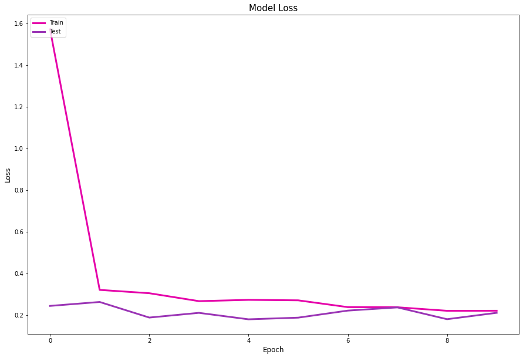

```python
plot_loss(adam_history)
```

Based on the result, Adam is much faster than SGD and the model converges in earlier epochs in comparison to SGD. Moreover, it works fine with default hyperparmeters.

### **Question 7**

```python
model_7 = make_feedforward_network(4800, 3200, 1600, optimizer=optimizers.Adam())
history_7 = model_7.fit(rescaled_train, validation_data=rescaled_test, epochs=20)
```

```python
predict(model_7, rescaled_test)
```

```
              precision    recall  f1-score   support

           0       0.96      0.89      0.92       116
           1       0.92      0.89      0.90       317
           2       0.95      0.97      0.96       855

    accuracy                           0.94      1288
   macro avg       0.94      0.92      0.93      1288
weighted avg       0.94      0.94      0.94      1288
```

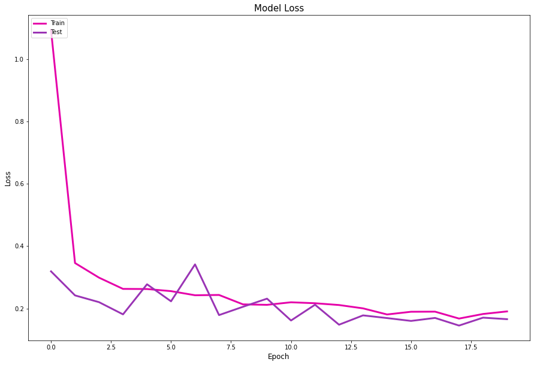

```python
plot_loss(history_7)
```

#### **Why we train neural network for multiple epochs?**

In each epoch, weights are updated for several times and the whole data is checked. It is undeniable that we want to get good performance on non-training data and usually that takes more than one pass over the training data. Moreover, it is typical that gradient descent does not reach a global or local minimum after the first epoch. So, training just one epoch can lead to underfitting. As a result, we use multiple epochs.

#### **Is it always good to train for more epochs?**

If we set the number of epochs to a very large number, it may lead to have and overfitted model, because we train the data for many times and our model will start to model the noises in our data and it is a sign of overfitting and the accuracy of the test data will be reduced.

#### **Techniques to avoid overfitting by controlling the number of epochs:**

- **Early stopping:** in this case we set the number of epochs to a really high number and you turn off the training when the improvement over next epochs is not satisfying.
- **Model Checkpoint:** here we once again set up a really high number of epochs and we simply save only the best model to a metric chosen. Once again we have a special callback for this scenario.

### **Question 8**

#### **Why MSE loss function is not good for classification problems?**

There are two reasons that MSE loss function is not good for classification problems:

Firstly, when we use MSE, it means we assume the underlying data has been generated from a normal distribution. In Bayesian terms this means we assume a Gaussian prior. While in fact, our dataset can be classified into three categories. As a result, it is not from a normal distribution.

Secondly, the MSE function is non-convex for classification. In other words, if a classification model is trained with MSE loss function, it is not guaranteed to minimize the loss function. This is because MSE function expects real-valued inputs in range (-∞, ∞), while classification models output probabilities in range (0,1) through the activation function.

#### **In which problems we use MSE loss function?**

We use this loss function for regression problems.

```python
model_8 = make_feedforward_network(4800, 3200, 1600, optimizer=optimizers.Adam(), loss=losses.mse)
history_8 = model_8.fit(rescaled_train, validation_data=rescaled_test, epochs=20)
```

```python
predict(model_8, rescaled_test)
```

```
              precision    recall  f1-score   support

           0       0.00      0.00      0.00       116
           1       0.00      0.00      0.00       317
           2       0.66      1.00      0.80       855

    accuracy                           0.66      1288
   macro avg       0.22      0.33      0.27      1288
weighted avg       0.44      0.66      0.53      1288
```

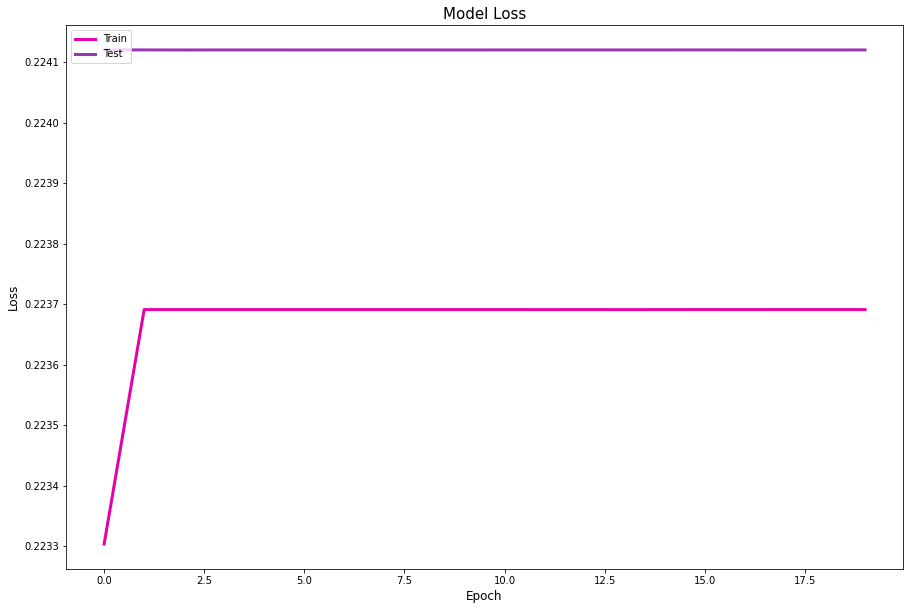

```python
plot_loss(history_8)
```

Based on the result, by using this loss function, the rate of the learning process decreased and it seems that it will not converge and it refers to the reasons that we mentioned above.

### **Question 9**

As we mentioned in previous parts, if we train our model for more epochs, the risk of overfitting will be increased. One of the techniques to avoid overfitting is to use regularization methods that we want to discuss in this part.

#### **Using Regularization**

```python
model_9_1 = make_feedforward_network(4800, 3200, 1600, optimizer=optimizers.Adam(), regularizer=regularizers.l2(0.0001))
history_9_1 = model_9_1.fit(rescaled_train, validation_data=rescaled_test, epochs=20)
```

```python
predict(model_9_1, rescaled_test)
```

```
              precision    recall  f1-score   support

           0       0.79      0.97      0.87       116
           1       0.95      0.84      0.89       317
           2       0.94      0.95      0.95       855

    accuracy                           0.93      1288
   macro avg       0.89      0.92      0.90      1288
weighted avg       0.93      0.93      0.93      1288
```

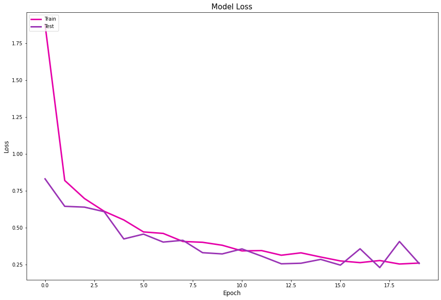

```python
plot_loss(history_9_1)
```

Based on the result, the loss curve is smoother and it shows that our model has not faced with overfitting, during the learning process.

#### **Using Dropout Layers**

```python
model_9_2 = make_feedforward_network_with_dropout(4800, 3200, 1600, 0.1, optimizer=optimizers.Adam())
history_9_2 = model_9_2.fit(rescaled_train, validation_data=rescaled_test, epochs=20)
```

```python
predict(model_9_2, rescaled_test)
```

```
              precision    recall  f1-score   support

           0       0.95      0.91      0.93       116
           1       0.89      0.92      0.91       317
           2       0.96      0.96      0.96       855

    accuracy                           0.94      1288
   macro avg       0.93      0.93      0.93      1288
weighted avg       0.95      0.94      0.95      1288
```

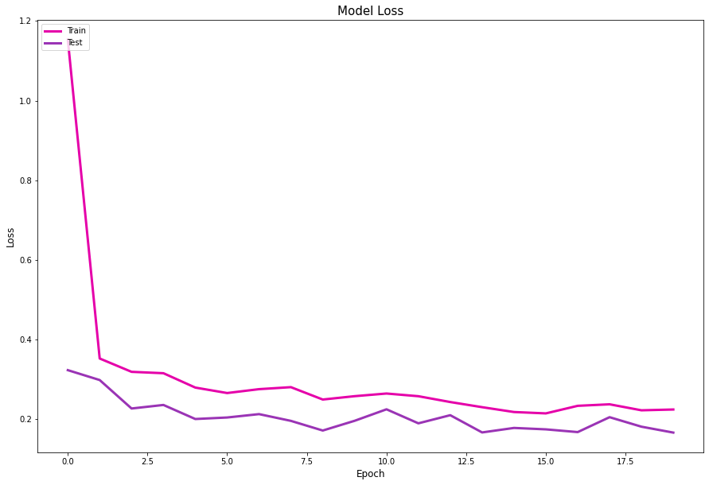

```python
plot_loss(history_9_2)
```

Here, the loss curve is smoother than the previous part and it seems that this method can deal with overfitting in a better way.

### **Conclusion**

In this computer assignment we learned that neural networks are good methods to solve image classification problems. Moreover, we were introduced to the method of Keras library. Finally, we learned how to tune the parameters in order to reach an optimal model.